# Simple linear regression homework

# Introduction

The file project_management.csv contains data sampled from the recent work schedule of a small construction company. Column estimated_length contains the estimated length of a building job in days, while column actual_length contains the actual recorded length of the job in days.

We are interested in determining the accuracy of the job estimations made by the company using simple linear regression, so we will eventually want to run a simple linear regression using actual_length as the dependent/response/outcome variable, and estimated_length as the independent/predictor/explanatory variable.

```r
library(tidyverse)
project <- read_csv("data/project_management.csv")
```

```
## ──────────────────────────────────────────────────────── Delimiter: "," dbl
## (3): ...1, estimated_length, actual_length
```

## Plot

Plot the data, taking estimated_length as the independent variable and actual_length as the dependent variable.

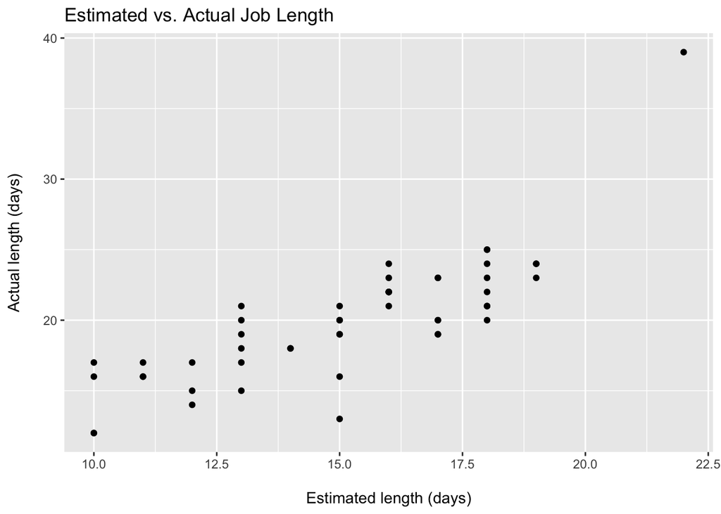

```r
project %>%
  ggplot(aes(x = estimated_length, y = actual_length)) +
  geom_point() +
  labs(
    x = "\nEstimated length (days)",
    y = "Actual length (days)\n",
    title = "Estimated vs. Actual Job Length"
  )
```

## Correlation coefficient Calculate the correlation coefficient of estimated_length and actual_length and interpret the value you obtain.

```r
project %>%
  summarise(correlation = cor(estimated_length, actual_length))
```

| correlation |
| --- |
| 0.8046597 |

These variables are very strongly positively correlated.

## Simple linear regression

Perform a simple linear regression using actual_length as the dependent variable, and estimated_length as the independent variable. Save the model object to a variable.

y ~ x, y is the outcome variable, and x the single explanatory variable.

- outcome/response/dependent: actual_length , y
- explanatory/predictor/independent: estimated_length, x

```r
model_job_length_days <- lm(actual_length ~ estimated_length,
  data = project
)
model_job_length_days
```

```
##
## Call:
## lm(formula = actual_length ~ estimated_length, data = project)
##
## Coefficients:
##      (Intercept)  estimated_length
##            1.416             1.223
```

ENDS